# Estimating AI Automation Risk Across U.S. Labor Markets

Kevin Ummel

Claude Gemini

## Executive Summary

This report presents findings from an analysis of AI automation risk across U.S. labor markets. By leveraging state-of-the-art AI systems to assess occupation-specific automation potential, we estimate that **29.9%** of U.S. wages could be at risk of automation by 2027, growing to **47.5%** by 2030.

Key findings include:

- White-collar occupations face higher automation risk than blue-collar occupations (49.0% vs 43.3% of wages at risk by 2030)
- There is minimal variation in automation risk between urban and rural areas (only 0.1 percentage point difference)
- Automation risk shows no meaningful correlation with political demographics (0.1 percentage point difference between Republican and Democratic districts)
- Several high-employment occupations face substantial automation risk, with Financial Specialists (63.0%) and Computer Specialists (57.4%) among the most exposed economically significant occupations

**Important Note**: These results reflect estimates of the likely *technical capabilities* of AI systems, not projections of actual implementation in the real world. As such, these estimates represent upper bounds on potential real-world rates of automation.

## Methodology

### Overview

This study employed a novel approach to estimate the potential impact of AI automation on U.S. labor markets. The analysis proceeded in three key stages:

1. **AI-based occupation analysis**: For each occupation category, we prompted Google Gemini (specifically the gemini-2.0-flash model) to provide detailed assessments of job functions and automation potential
2. **Occupation-level automation risk estimation**: Using the AI assessments, we calculated the percentage of wages at risk of automation by 2027 and 2030
3. **Geographic and demographic analysis**: We combined automation risk estimates with American Community Survey (ACS) 2022 data to analyze patterns across geographic regions, urban/rural divides, and political dimensions

### AI Prompt Design

The AI system was prompted with a three-stage process for each occupation:

1. First, the AI was asked to identify the core job functions, associated tasks, and percentage of labor hours for each occupation
2. Next, the AI was asked to assess the likely capabilities of AI systems by 2027 and 2030 in performing these job functions
3. Finally, the AI provided structured estimates of the percentage of current labor hours that could be automated by 2027 and 2030, with supporting reasoning

This structured approach allowed for consistent assessment across diverse occupations and clear disambiguation between near-term (2027) and medium-term (2030) automation potential.

### Data Integration

We merged the AI-generated automation risk estimates with 2022 American Community Survey (ACS) microdata to understand how automation risk distributes across:

- States and congressional districts
- Urban versus rural areas
- White-collar versus blue-collar occupations
- Political dimensions using Cook Political Voting Index (PVI)

## National Automation Risk Estimates

Our analysis estimates that approximately **29.9%** of U.S. wages are at risk of automation by 2027, increasing to **47.5%** by 2030. These figures represent the percentage of current labor income that could potentially be performed by AI systems based on projected technical capabilities.

While we calculated both hours-at-risk and wages-at-risk metrics, the results were similar. For simplicity, this report focuses primarily on wages-at-risk, as this metric better reflects the economic impact of automation.

## Occupational Analysis

Our analysis reveals significant variation in automation risk across different occupations, with some jobs facing much higher potential disruption than others. This section explores the occupations most vulnerable to AI automation, those that appear most resilient, and examines automation risk among the largest occupational categories in the U.S. labor market.

### Most At-Risk Occupations

The following chart displays the ten occupations with the highest estimated automation risk by 2030:

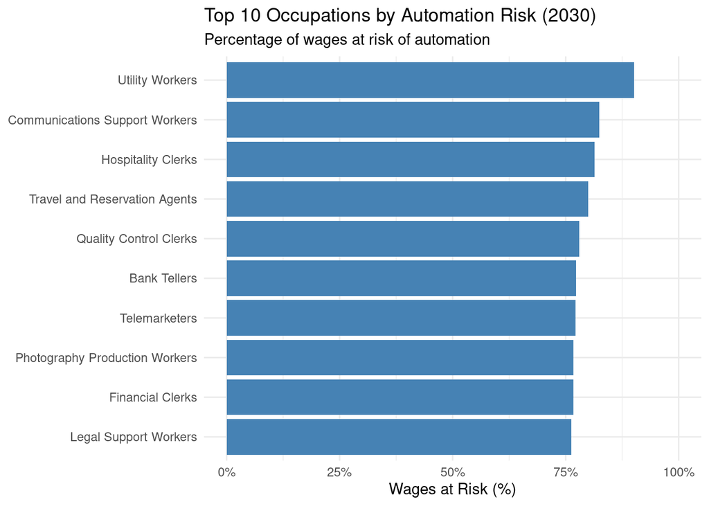

These highly vulnerable occupations share several common characteristics that make them susceptible to AI automation:

1. **Information processing tasks**: Many of these jobs involve routine information handling, data entry, record-keeping, and standardized customer interactions
2. **Structured workflows**: These occupations typically follow well-defined procedures with predictable inputs and outputs
3. **Digital mediation**: Many of these roles already conduct most of their work through digital interfaces, making them easier targets for AI systems to replace
4. **Limited physical manipulation**: These jobs generally don’t require complex physical dexterity or navigation of unpredictable physical environments

For example, Utility Workers (90.1% of wages at risk) and Communications Support Workers (82.4%) face high automation risk because core aspects of their work—monitoring systems, managing routine communications, and processing standardized information—align well with emerging AI capabilities. Similarly, roles like Bank Tellers (77.3%) and Financial Clerks (76.7%) involve routine financial transactions and standardized customer service that AI systems are increasingly capable of handling.

### Least At-Risk Occupations

In contrast, the following chart shows the ten occupations with the lowest estimated automation risk by 2030:

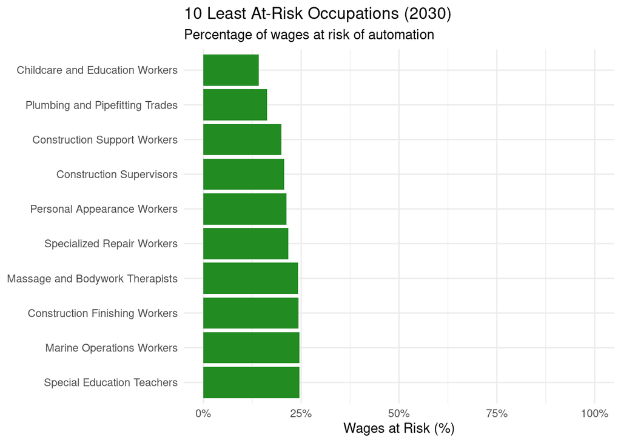

These more resilient occupations share characteristics that make them challenging for AI systems to automate:

1. **Physical dexterity and environmental adaptation**: Many involve complex physical skills in variable environments (e.g., Plumbing and Pipefitting Trades at 16.3% risk)
2. **Social and emotional intelligence**: Jobs like Childcare and Education Workers (14.2% risk) and Special Education Teachers (24.6% risk) require nuanced human interaction, empathy, and relationship building
3. **On-site problem solving**: Occupations such as Construction Supervisors (20.6% risk) require real-time decision-making and adaptation to changing physical conditions
4. **Embodied services**: Personal Appearance Workers (21.2% risk) and Massage Therapists (24.2% risk) provide physical services that require human touch and personalized attention

It’s worth noting that even these “low-risk” occupations still face non-trivial automation potential, with 14-25% of wages at risk. This suggests that while these jobs may be more resilient, they are not immune to the effects of AI automation.

### Largest Occupations by Labor Hours

To understand the economic significance of automation risk, we analyzed the ten largest occupational categories by percentage of national labor hours:

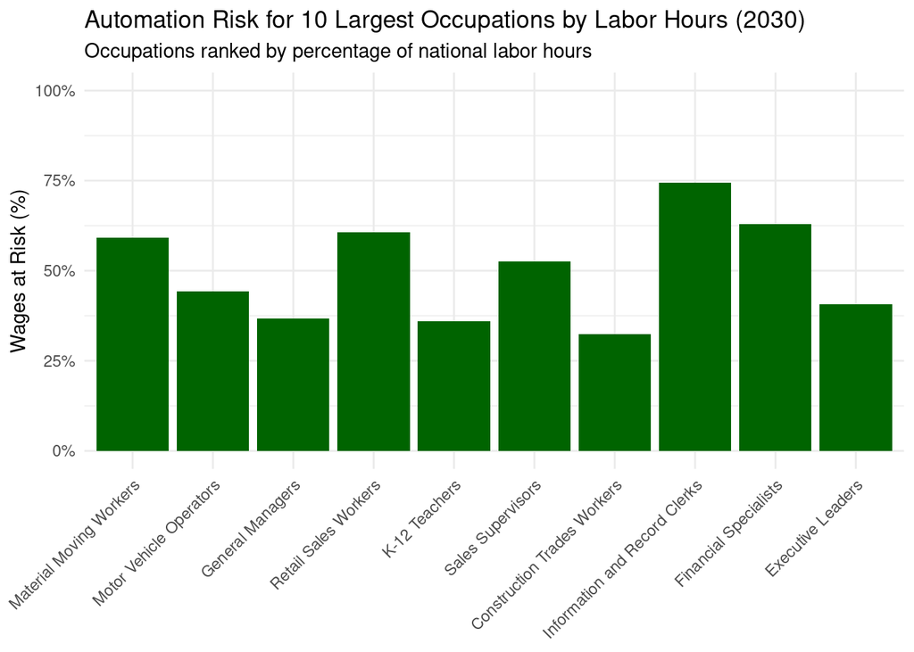

This visualization highlights several important patterns:

1. **Wide variation in risk among major occupations**: Automation risk ranges from 32.4% (Construction Trades Workers) to 74.4% (Information and Record Clerks) among the largest occupational categories
2. **High-hours, high-risk combinations**: Several occupations that represent large portions of the labor market also face high automation risk, including Retail Sales Workers (3.01% of hours, 60.7% risk) and Information and Record Clerks (2.26% of hours, 74.4% risk)
3. **Mixed risk for management roles**: While Executive Leaders (2.14% of hours) and General Managers (3.24% of hours) face moderate risk (40.7% and 36.7% respectively), Sales Supervisors have higher automation risk (52.5%)
4. **Education’s relative resilience**: K-12 Teachers, representing 2.79% of national labor hours, show lower automation risk (35.9%), consistent with our finding that occupations requiring complex human interaction may be more protected
5. **Potential transportation impact**: Motor Vehicle Operators, accounting for 3.30% of labor hours, face a substantial 44.2% risk, highlighting the significant economic impact that autonomous vehicle technology could have if it advances as projected

Together, these ten occupational categories represent nearly 28% of all labor hours in the U.S. economy, and on a weighted-average basis, 48.9% of their wages are estimated to be at risk of automation by 2030. This suggests that AI automation is likely to impact a substantial portion of the core U.S. labor market rather than being limited to niche occupations.

### White-Collar vs. Blue-Collar Work

The following chart compares automation risk between white-collar and blue-collar occupations:

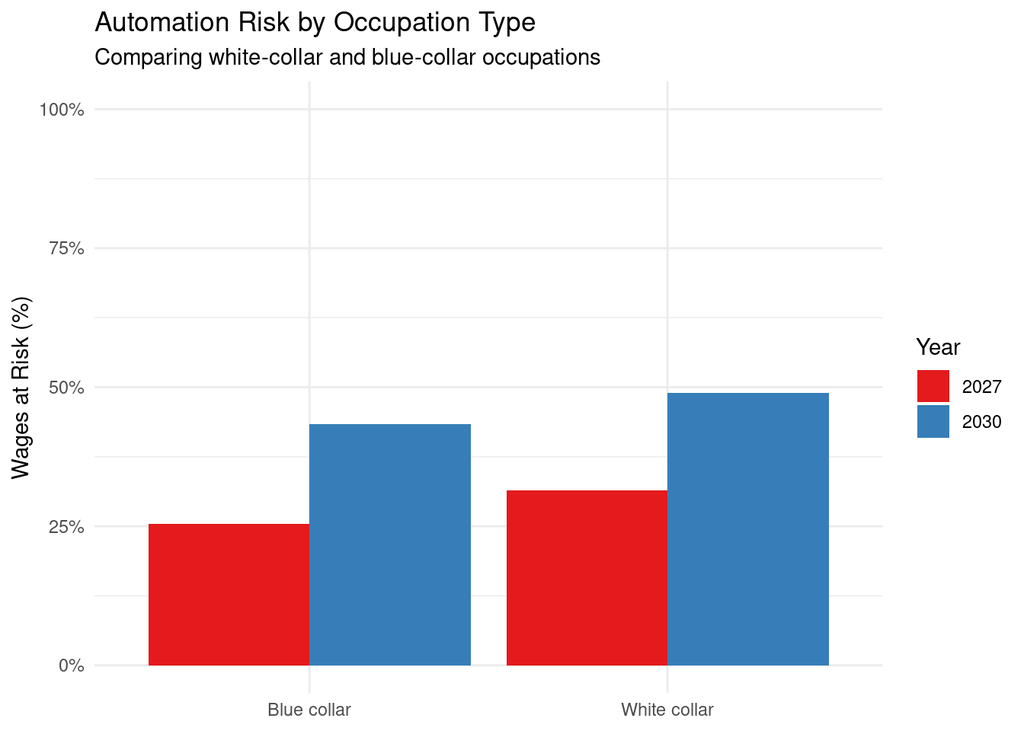

Our analysis reveals a 5.7 percentage point difference in automation risk between white-collar and blue-collar occupations. White-collar occupations (49.0% of wages at risk by 2030) face higher potential automation from emerging AI systems than blue-collar occupations (43.3% at risk by 2030). White-collar jobs, which are generally more dependent on information processing, analysis, and communication, appear more susceptible to emerging AI capabilities compared to blue-collar occupations that often involve physical manipulation, spatial awareness, and environment navigation.

This finding represents a reversal of historical automation patterns, where routine manual labor was more easily automated than cognitive work. It reflects the strengths of current AI systems, which excel at processing language, recognizing patterns, and making decisions based on large amounts of structured and unstructured data—capabilities that align closely with many white-collar job functions.

These occupation-specific findings suggest that AI automation is likely to have differentiated effects across the labor market, with some occupations facing much higher potential disruption than others. The projected impact on large occupational categories and the higher risk for white-collar jobs indicate that the economic effects of AI could be both substantial and different from previous waves of automation.

This finding may seem counterintuitive compared to earlier waves of automation, where routine manual tasks were more susceptible to automation than cognitive tasks. However, it aligns with the capabilities of current and near-future AI systems, which excel at language processing, pattern recognition, and decision-making based on diverse information.

## Geographic Analysis

### Urban vs. Rural Differences

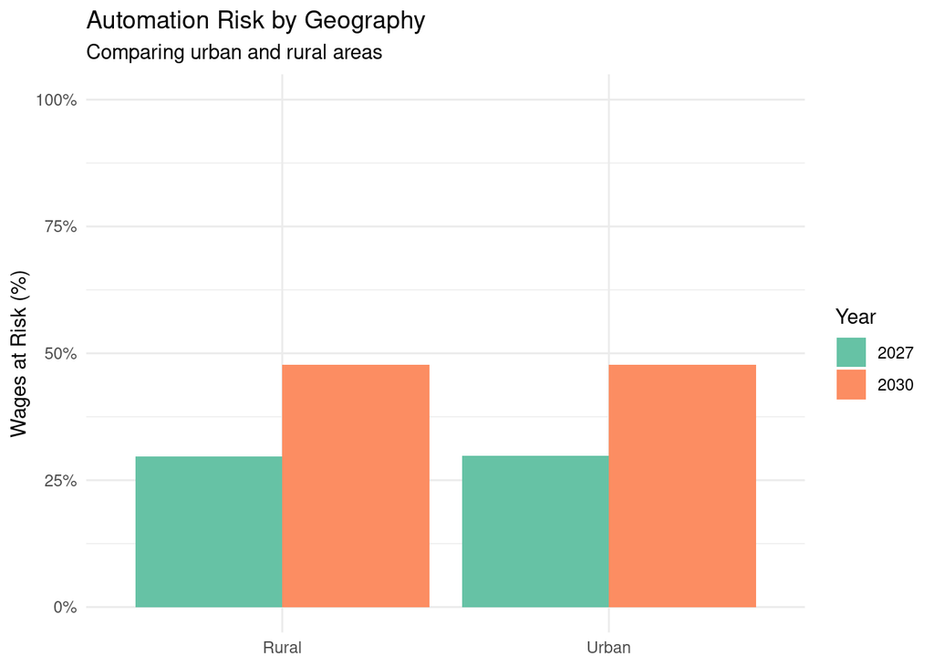

Our analysis shows minimal differences in automation risk between urban and rural areas, with only a 0.1 percentage point difference (urban areas at 47.8% versus rural areas at 47.7% of wages at risk by 2030). While urban centers typically have higher concentrations of white-collar knowledge workers and rural areas have different occupation mixes, the overall automation risk is remarkably similar across these geographic categories.

### State-Level Analysis

Our analysis of state-level automation risk reveals remarkably small differences across states. The highest-risk states are the District of Columbia (49.1%), Georgia (48.5%), Illinois (48.4%), Tennessee (48.4%), and Wisconsin (48.3%). The lowest-risk states are Wyoming (45.7%), Alaska (46.0%), Vermont (46.0%), New Mexico (46.4%), and North Dakota (46.5%).

The narrow range of risk values (just 3.4 percentage points between the highest and lowest states) suggests that automation risk is distributed relatively evenly across the country. This pattern aligns with our findings on urban/rural differences and indicates that AI automation is likely to have broad-based effects across geographic regions rather than being concentrated in particular areas.

There is no clear regional pattern to the distribution of automation risk, with both high and low-risk states distributed across different parts of the country. The minimal state-level variation suggests that policy responses may need to be national in scope rather than targeted at specific regions.

## Political Dimension Analysis

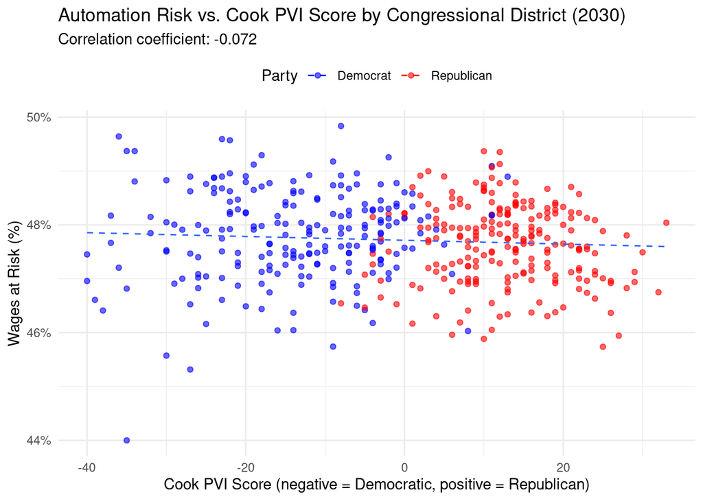

Our analysis of automation risk across congressional districts shows virtually no relationship between political leaning and automation risk. The correlation coefficient between Cook PVI scores and automation risk is just -0.072, indicating a negligible association. Democratic districts have an average automation risk of 47.8%, while Republican districts have a nearly identical average of 47.7%.

The scatterplot above illustrates this lack of correlation, with automation risk values tightly clustered regardless of political leaning. This finding suggests that AI automation is likely to affect constituencies represented by both major parties with remarkably similar intensity.

## Discussion and Implications

## Main Findings

1. **Widespread and relatively uniform impact**: AI automation capability is projected to impact a substantial portion of the U.S. labor market (47.5% of wages at risk by 2030), with remarkably little variation across geographic and political lines
2. **White-collar vulnerability**: Unlike previous waves of automation that primarily affected blue-collar jobs, our analysis suggests that white-collar occupations face higher automation risk from emerging AI technologies (49.0% vs 43.3%)
3. **Occupation-specific variation**: While geographic and political patterns show minimal differences, there is substantial variation across occupations, from high-risk jobs like Utility Workers (90.1%) and Communications Support Workers (82.4%) to lower-risk occupations like Plumbing and Pipefitting Trades (16.3%) and Childcare and Education Workers (14.2%)
4. **Economic significance**: Many economically significant occupations face substantial automation risk, including Financial Specialists (63.0% of wages at risk), Computer Specialists (57.4%), and Sales Supervisors (52.5%)

### Limitations

Several important limitations should be considered when interpreting these results:

1. **Technical capability ≠ implementation**: Our estimates reflect the projected technical capabilities of AI systems, not actual implementation rates, which may be significantly lower due to economic, regulatory, social, and organizational factors
2. **Occupation-level analysis**: The occupation-level approach may mask important variations within occupations, where some tasks may be more automatable than others
3. **Adaptive workforce**: The analysis does not account for how occupations may evolve in response to AI, with workers potentially adapting their roles to complement rather than compete with AI
4. **AI advancement uncertainty**: Projections of AI capabilities by 2027 and 2030 involve inherent uncertainty, and actual capabilities may differ from current expectations

### Policy Implications

The findings from this analysis have several potential implications for policymakers:

1. **Workforce development**: Investments in education and training programs could help workers adapt to changing skill demands
2. **Social safety nets**: Enhanced unemployment benefits, wage insurance, or other social safety nets may be needed to support workers displaced by automation
3. **Place-based policies**: While automation risk shows modest geographic variation, targeted interventions in vulnerable communities could help mitigate concentrated negative impacts
4. **Regulatory frameworks**: Policies governing AI deployment in the workplace could influence the pace and scope of automation

## Conclusion

This analysis provides a data-driven assessment of the potential impact of AI automation on U.S. labor markets by 2027 and 2030. By estimating occupation-specific automation risk and examining patterns across geographic, demographic, and political dimensions, we offer a nuanced view of how emerging AI technologies might reshape the American workforce.

The results suggest that a substantial portion of current labor income could potentially be automated by AI systems within the next 3-5 years, with 29.9% of wages at risk by 2027 and 47.5% by 2030. However, it is crucial to emphasize that these estimates represent upper bounds based on projected technical capabilities, not forecasts of actual automation levels, which will depend on many additional factors including economic considerations, regulatory environments, organizational readiness, and worker adaptation.

As AI technologies continue to advance, ongoing research and policy attention will be essential to ensure that the benefits of automation are broadly shared and that appropriate supports are in place for affected workers and communities.